# Cardio Good Fitness Project / Yeoman Yoon.

### Import pandas, numpy, seaborn, etc for analysis

```python
import pandas as pd
import numpy as np
import seaborn as sns
import matplotlib.pyplot as plt
%matplotlib inline
import warnings
pd.set_option('display.float_format', lambda x: '%.5f' % x) # To supress numerical display in scientific notations
```

### Store the data using pandas

```python
data = pd.read_csv('CardioGoodFitness.csv')
```

### Dataset:

- Product - the model no. of the treadmill
- Age - in no of years, of the customer
- Gender - of the customer
- Education - in no. of years, of the customer
- Marital Status - of the customer
- Usage - Avg. # times the customer wants to use the treadmill every week
- Fitness - Self rated fitness score of the customer (5 - very fit, 1 - very unfit)
- Income - of the customer
- Miles- expected to run

### Quick overview of the data

```python
data.isnull().sum() # data is not missing any values.
```

```
Product          0
Age              0
Gender           0
Education        0
MaritalStatus    0
Usage            0
Fitness          0
Income           0
Miles            0
dtype: int64
```

```python
data.head(10)
```

|  | Product | Age | Gender | Education | MaritalStatus | Usage | Fitness | Income | Miles |
| --- | --- | --- | --- | --- | --- | --- | --- | --- | --- |
| 0 | TM195 | 18 | Male | 14 | Single | 3 | 4 | 29562 | 112 |
| 1 | TM195 | 19 | Male | 15 | Single | 2 | 3 | 31836 | 75 |
| 2 | TM195 | 19 | Female | 14 | Partnered | 4 | 3 | 30699 | 66 |
| 3 | TM195 | 19 | Male | 12 | Single | 3 | 3 | 32973 | 85 |
| 4 | TM195 | 20 | Male | 13 | Partnered | 4 | 2 | 35247 | 47 |
| 5 | TM195 | 20 | Female | 14 | Partnered | 3 | 3 | 32973 | 66 |
| 6 | TM195 | 21 | Female | 14 | Partnered | 3 | 3 | 35247 | 75 |
| 7 | TM195 | 21 | Male | 13 | Single | 3 | 3 | 32973 | 85 |
| 8 | TM195 | 21 | Male | 15 | Single | 5 | 4 | 35247 | 141 |
| 9 | TM195 | 21 | Female | 15 | Partnered | 2 | 3 | 37521 | 85 |

```python
data.describe()
```

|  | Age | Education | Usage | Fitness | Income | Miles |
| --- | --- | --- | --- | --- | --- | --- |
| count | 180.00000 | 180.00000 | 180.00000 | 180.00000 | 180.00000 | 180.00000 |
| mean | 28.78889 | 15.57222 | 3.45556 | 3.31111 | 53719.57778 | 103.19444 |
| std | 6.94350 | 1.61705 | 1.08480 | 0.95887 | 16506.68423 | 51.86360 |
| min | 18.00000 | 12.00000 | 2.00000 | 1.00000 | 29562.00000 | 21.00000 |
| 25% | 24.00000 | 14.00000 | 3.00000 | 3.00000 | 44058.75000 | 66.00000 |
| 50% | 26.00000 | 16.00000 | 3.00000 | 3.00000 | 50596.50000 | 94.00000 |
| 75% | 33.00000 | 16.00000 | 4.00000 | 4.00000 | 58668.00000 | 114.75000 |
| max | 50.00000 | 21.00000 | 7.00000 | 5.00000 | 104581.00000 | 360.00000 |

```python
data.info()
```

```
<class 'pandas.core.frame.DataFrame'>
RangeIndex: 180 entries, 0 to 179
Data columns (total 9 columns):
Product          180 non-null object
Age              180 non-null int64
Gender           180 non-null object
Education        180 non-null int64
MaritalStatus    180 non-null object
Usage            180 non-null int64
Fitness          180 non-null int64
Income           180 non-null int64
Miles            180 non-null int64
dtypes: int64(6), object(3)
memory usage: 12.8+ KB
```

### See how many products we have

```python
data.Product.unique()
```

```
array(['TM195', 'TM498', 'TM798'], dtype=object)
```

# Observation:

## Univariable analysis

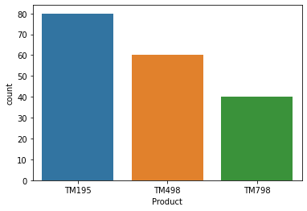

```python
sns.countplot(data['Product'])
```

Assuming there is no bias in the data, TM195 is the most popular product among consumers followed by TM498 and TM798.

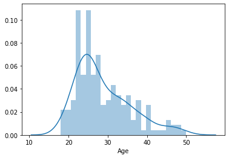

```python
sns.distplot(data['Age'], bins=25)
# plt.hist(data['Age'], bins =25)
```

As written in the data description, mean is 28.79 and median is 26. It is slightly right skewed.

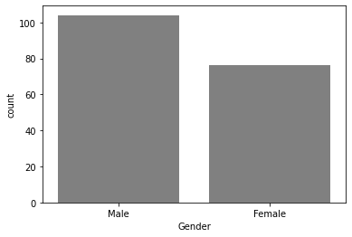

```python
sns.countplot(data['Gender'], color = 'grey') # removed colors since there is only two categories
```

Assuming the data is collected randomly, we have slighlty more male buyers.

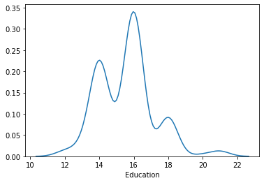

```python
sns.distplot(data['Education'], hist = False) # removed hist for visual purpose. The bars are sticking too high.
```

Buyers have 15.57 years of education. Seems to have gap (camel shape) becuase many collages have curriculum of either 2 years or 4 years.

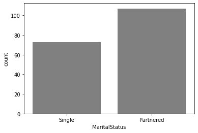

```python
sns.countplot(data['MaritalStatus'], color = 'grey') # removed colors since there is only two categories
```

We have more partnered buyers. It is considered independent from gender with univariable analysis.

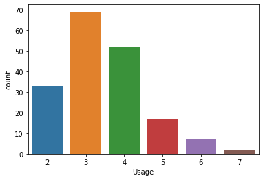

```python
sns.countplot(data['Usage'])
```

Overall, buyers use the treadmill 3.4 times per week.

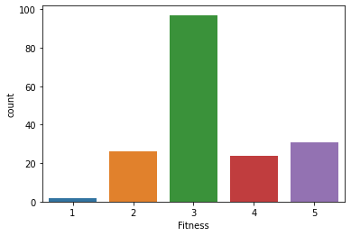

```python
sns.countplot(data['Fitness'])
```

Buyers evaluate themselves to have 3.31/5.00 fitness level.

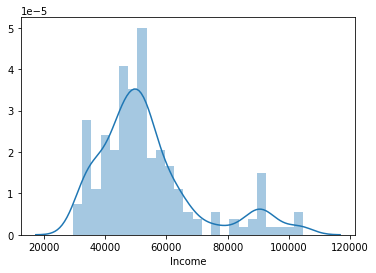

```python
sns.distplot(data['Income'], bins=25)
```

Buyers make about ＄53k per year in average.  
**It is important that graph is making somewhat of camel shape around ＄50,000 area and ＄90,000 area.**  
Later we can observe if the grouping happens.

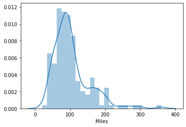

```python
sns.distplot(data['Miles'], bins = 25)
```

Buyers run around 103 Miles (per week). Some runs very heavily.

### Conclusion from Univariable:

Before going into Multivariable Analysis, we can imagine how the correlation is going to be like. Usage and Running Miles must have high correlations, Age and Income are also expected to have high correlation.

## Multivariable Analysis

### Quick overview in correlations of data.

Lets observe the correlation of each data as well.

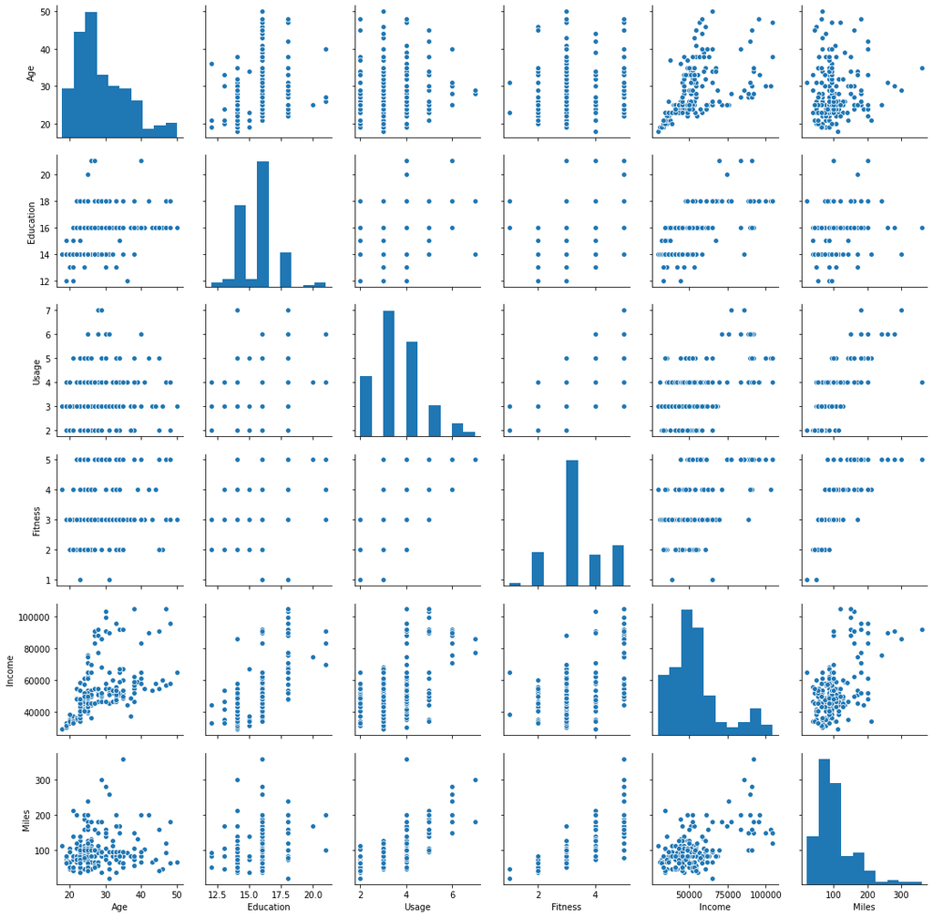

```python
sns.pairplot(data)
```

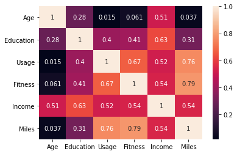

```python
sns.heatmap(data.corr(), annot=True)
```

### Now, Lets see how the customer profile works for each products.

### Categorical vs Categorical

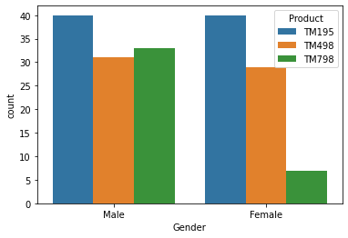

```python
# sns.countplot(data['Product'], hue= data['Gender']);
sns.countplot(data['Gender'], hue= data['Product']);
```

Females don't prefer buying TM798.

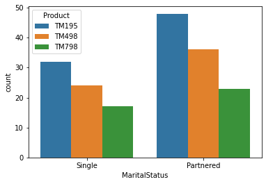

```python
# sns.countplot(data['Product'], hue= data['MaritalStatus']);
sns.countplot(data['MaritalStatus'], hue= data['Product']);
```

We have more partnered people buying the product generally. It seems very normal, because data is collected from people older than 18. The proportion of purchased product seems consistent over marrage.  
**Knowing that we only have little females buying TM798, it is likely most or singles customers who bought TM798 are male.**

### Categorical vs Numerical

I chose box plot or violin plot because this data in particular looks hallow since we only have 180 data.

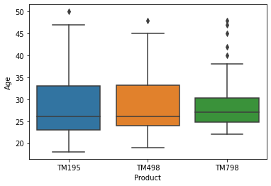

```python
sns.boxplot( data['Product'], data['Age']); # I chose box plot over violin because it shows median more clear
```

Most of Treadmill buyers are rather young. Although we have some TM798 buyers over age of 40, most of them are 25-30 years old.

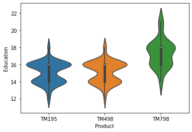

```python
sns.violinplot(data['Product'], data['Education']);
```

TM195, TM498 buyers have very similar education background. But, TM798 seems to have higher education.

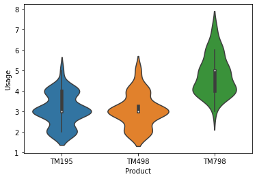

```python
sns.violinplot(data['Product'], data['Usage']);
```

TM798 buyers use treadmill more often than TM195 and TM498 buyers.

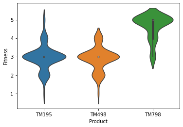

```python
sns.violinplot(data['Product'], data['Fitness']);
```

TM798 buyers seem to evaluate themselves to be more fit, and they are probably more fit as well.  
Ppeople who buys treadmill are probably already somewhat fit or are wanting to be more fit.)

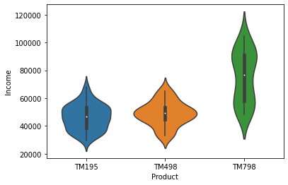

```python
sns.violinplot(data['Product'], data['Income']);
```

Most, if not all, TM195 and TM498 buyers make less than 80k per year. Yet, TM798 buyers have pretty even distribution of income .  
**This can be an indicator that TM798 buyers are wealthy enough or they value exercise more.**

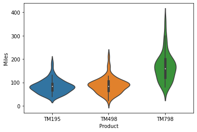

```python
sns.violinplot(data['Product'], data['Miles']);
```

TM798 buyers actually run more miles than TM195 and TM498 buyers.  
Most people, if not all, who run more than 250 miles use TM798.

## Conclusion and Recommendation

Main customers are relatively young. This should be interpreted in two ways:

1. Since The running activity is more popular to younger people, it is important to let marketing teams target younger customers when advertising. Let them choose the right platform and use suitable models.
2. Even though running is popular for the younger generation, older people also desire to exercise. The R & D Team (Research and Development Team) should focus on creating a new product model that targets older people. (e.g. Stairs treadmill, bicycle) Older people are willing to spend more in buying products as long as the product quality supports it.

It is observed that TM798 is more popular for intense runners and people who are wealthier. (Assume the product is more expensive as well.) When new technology gets developed, it is better to implement it on TM798 over other products because the price is not the attractive point of TM798. It is not as critical to raise the price for TM798 as long as it supports advanced technology.